# AIS-Delaware-Ship-Traffic-R_Markdown-8-23-2019_V2

Shane Cone @Microscone

8/26/2019

```r
setwd("D:\\DAQ\\CMV-AIS")
getwd()
```

```
## [1] "D:/DAQ/CMV-AIS"
```

```r
#install.packages("dplyr")
#install.packages("lubridate")
#install.packages("magrittr")
#install.packages("forcats")
#install.packages("lubridate")
#install.packages("OpenStreetMap")
#install.packages("tidyverse")
#install.packages("rlang")
#install.packages("rmarkdown")
library(rmarkdown)
library(stringi)
library(knitr)
library(rlang)
library(dplyr)
library(lubridate)
library(tidyverse)
```

Read the file for June 2017

```r
a <- read.csv("AIS_2017_06_Zone18.csv")
```

View details of data file. **An important find here is under Draft!** There are 35 million observations (records), but ~24 million draft records are NA!

Also, a note on inter-month differences.. The January, 2017 file contains ~24 million records, whereas this June file containes ~35 million records.

```r
str(a)
```

```
## 'data.frame':    35624575 obs. of  16 variables:
##  $ MMSI        : int  367606840 367003470 367520980 338184034 367000930 338147934 367072810 303029000 367772272 338154307 ...
##  $ BaseDateTime: Factor w/ 2591788 levels "2017-06-01T00:00:00",..: 5 4 2 10 27 44 68 71 76 98 ...
##  $ LAT         : num  38.9 36.7 35.2 40.8 40.7 ...
##  $ LON         : num  -76.5 -76.1 -76.1 -74 -74.1 ...
##  $ SOG         : num  0 5.4 11.8 0.3 0 0 0 0 0 8.5 ...
##  $ COG         : num  10.9 170 98.4 143.5 -191 ...
##  $ Heading     : num  511 511 511 511 217 511 511 511 511 511 ...
##  $ VesselName  : Factor w/ 5889 levels "","'S WONDERFUL",..: 1 1 4685 1 1 1 1 4587 1 1 ...
##  $ IMO         : Factor w/ 2134 levels "","IMO0000001",..: 1 1 1935 1 1 1 1 1 1 1 ...
##  $ CallSign    : Factor w/ 4511 levels "","26144","2ABB2",..: 1 1 2829 1 1 1 1 1843 1 1 ...
##  $ VesselType  : int  NA NA 1012 NA NA NA NA 1025 NA NA ...
##  $ Status      : Factor w/ 17 levels "","aground","AIS-SART (active); MOB-AIS; EPIRB-AIS",..: 1 17 17 1 7 1 1 17 15 1 ...
##  $ Length      : num  NA NA 62.5 NA NA ...
##  $ Width       : num  NA NA 15.2 NA NA ...
##  $ Draft       : num  NA NA NA NA NA NA NA NA NA NA ...
##  $ Cargo       : int  NA NA NA NA NA NA NA NA NA NA ...
```

```r
summary(a)
```

```
##       MMSI                        BaseDateTime           LAT
##  Min.   :1.000e+00   2017-06-07T23:59:59:     111   Min.   :12.29
##  1st Qu.:3.383e+08   2017-06-09T23:59:59:      97   1st Qu.:37.61
##  Median :3.671e+08   2017-06-25T00:00:00:      92   Median :39.53
##  Mean   :3.636e+08   2017-06-08T00:00:00:      91   Mean   :39.26
##  3rd Qu.:3.676e+08   2017-06-24T00:00:01:      90   3rd Qu.:40.69
##  Max.   :1.074e+09   2017-06-07T00:00:01:      84   Max.   :87.65
##                      (Other)            :35624010
##       LON              SOG               COG             Heading
##  Min.   :-78.00   Min.   :-51.200   Min.   :-204.80   Min.   :  0.0
##  1st Qu.:-76.29   1st Qu.:  0.000   1st Qu.:-129.00   1st Qu.:235.0
##  Median :-74.88   Median :  0.100   Median : -49.60   Median :511.0
##  Mean   :-74.98   Mean   :  3.156   Mean   : -16.74   Mean   :387.8
##  3rd Qu.:-74.01   3rd Qu.:  5.700   3rd Qu.:  85.10   3rd Qu.:511.0
##  Max.   :-72.00   Max.   : 51.100   Max.   : 204.70   Max.   :511.0
##
##          VesselName               IMO              CallSign
##               : 1998101             :19611916          : 6938532
##  BROOKLYN     :   76707   IMO5068875:   39459   WDH8056:   45485
##  PATUXENT     :   68864   IMO7423079:   38911   WDD9658:   41231
##  NEW JERSEY   :   58951   IMO9804681:   38464   VDLK   :   39459
##  POTOMAC      :   56564   IMO9707493:   38410   VA3418 :   38911
##  CAPE HATTERAS:   53913   IMO8644369:   38213   WDI9336:   38464
##  (Other)      :33311475   (Other)   :15819202   (Other):28482493
##    VesselType                             Status             Length
##  Min.   :   0      under way using engine    :15766226   Min.   :  0
##  1st Qu.:1005                                :11583032   1st Qu.: 19
##  Median :1019      undefined                 : 3046303   Median : 27
##  Mean   : 976      moored                    : 2892229   Mean   : 55
##  3rd Qu.:1025      at anchor                 :  969580   3rd Qu.: 41
##  Max.   :1025      restricted maneuverability:  515799   Max.   :366
##  NA's   :3725351   (Other)                   :  851406   NA's   :6486915
##      Width              Draft              Cargo
##  Min.   : 0         Min.   :-12        Min.   :  0
##  1st Qu.: 7         1st Qu.:  4        1st Qu.: 32
##  Median : 9         Median :  4        Median : 52
##  Mean   :13         Mean   :  6        Mean   : 50
##  3rd Qu.:12         3rd Qu.: 10        3rd Qu.: 69
##  Max.   :70         Max.   : 22        Max.   :128
##  NA's   :12120337   NA's   :24573565   NA's   :23626449
```

```r
sum(is.na(a$MMSI))
```

```
## [1] 0
```

```r
sum(is.na(a$IMO))
```

```
## [1] 0
```

**These figures and results below are from the January 2017 month analysis. ###January 2017 The following code looks at MMSI vs IMO. There are 3727 unique MMSI codes, and 35 of them are “0” (no NULL in field, according to above results, but there are 0’s!).

For IMO#, there are 1993 unique IMO numbers, and no “NULLS” and no 0’s. However, it is a factor, and includes a blank level, with, according to the table, 9,336,777 records as blank!

Therefore, MMSI is the best/most complete identifier of ships, by far.

###June 2017 For the June 2017 analysis, there are no “0” records for either field, however, a very large number of the IMO records are blank.

```r
length(unique(a$MMSI))
```

```
## [1] 7316
```

```r
sum(a$MMSI == 0)
```

```
## [1] 0
```

```r
length(unique(a$IMO))
```

```
## [1] 2134
```

```r
sum(a$IMO == 0)
```

```
## [1] 0
```

```r
sum(a$IMO == "")
```

```
## [1] 19611916
```

```r
## the below lines of codes print all of the levels for ...$IMO field. I printed them to take a peak, but it't not very helfpul
##table(a$IMO)
```

## Data prep and subsetting based on location

Define the data preperation function

```r
data.prep <- function(data, lower, upper, left, right, NULL.A){
b <- subset(a, a$LAT >= lower & LAT <= upper & LON <= right & LON >= left)
print("Taking the absolute value of SOG...")
b$SOG <- abs(b$SOG)
print("Formatting date-time records...")
b$BaseDateTime <- ymd_hms(b$BaseDateTime)
b$Day <- day(b$BaseDateTime)
b$wDay <- wday(b$BaseDateTime)
region <<- b
print("data prep complete")
}
```

```r
##THIS SECTION IS CURRENTLY UNDER CONSTRUCTION. PLEASE MOVE ALONG

##had to install, set up, and create API key for this step, as google has put a LOCK on it's maps...
##If this section does not work, sorry!
#AIS_Polygon  <- read.csv("AIS GPS Selection.csv")

#library(OpenStreetMap)
#Delaware <- c(lon = -75.77944444, lat = 38.71333333)

# Get map at zoom level 5: map_5
#map_DE <- openmap(location = Delaware, source = "stamen", zoom = 5, scale = 1)
#plot(map_DE)

# Plot map at zoom level 3
#ggmap(map_5)
```

Conduct data prep on full dataset

```r
data.prep(data = a, lower = 38.71333333, upper = 39.80638889, left = -75.77944444, right = -75.035110
, NULL.A = FALSE)
```

```
## [1] "Taking the absolute value of SOG..."
## [1] "Formatting date-time records..."
## [1] "data prep complete"
```

```r
Delaware_Riv <- region
region <- NULL
Delaware_Riv$region <- "Delaware River"
write.csv(Delaware_Riv, "AIS_limited_Delaware_Riv.csv")
Delaware_Riv_Ais_full <- read.csv("AIS_limited_Delaware_Riv.csv"
)
```

```r
head(Delaware_Riv_Ais_full)
```

```
##     X      MMSI        BaseDateTime      LAT       LON  SOG    COG Heading
## 1  50 367090620 2017-06-01 00:00:48 38.94026 -75.31775  0.0 -190.1     511
## 2  60 367090620 2017-06-01 00:02:18 38.94026 -75.31775  0.0 -190.5     511
## 3  67 338099013 2017-06-01 00:01:42 39.24301 -75.51588  0.0   46.1     511
## 4  92 416490000 2017-06-01 00:00:04 39.45650 -75.56017 14.7  159.0     152
## 5 110 416490000 2017-06-01 00:01:11 39.45267 -75.55733 14.1  140.0     136
## 6 129 367635560 2017-06-01 00:02:02 39.57148 -75.59026  0.0   32.3     511
##      VesselName        IMO CallSign VesselType                 Status
## 1    BREAKWATER             WYH7020       1012 under way using engine
## 2    BREAKWATER             WYH7020       1012 under way using engine
## 3   FIRST STATE                           1020
## 4  YM EVOLUTION IMO9496460     BLHN       1004 under way using engine
## 5  YM EVOLUTION IMO9496460     BLHN       1004 under way using engine
## 6 GREEK'S FOLLY             WDH6202       1019
##   Length Width Draft Cargo Day wDay         region
## 1  14.72   4.5    NA    50   1    5 Delaware River
## 2  14.72   4.5    NA    50   1    5 Delaware River
## 3  18.90    NA    NA    NA   1    5 Delaware River
## 4 259.00  37.3  11.8    NA   1    5 Delaware River
## 5 259.00  37.3  11.8    NA   1    5 Delaware River
## 6  12.95    NA    NA    NA   1    5 Delaware River
```

```r
str(Delaware_Riv_Ais_full)
```

```
## 'data.frame':    1205401 obs. of  20 variables:
##  $ X           : int  50 60 67 92 110 129 178 310 397 402 ...
##  $ MMSI        : int  367090620 367090620 338099013 416490000 416490000 367635560 367080670 338121224 367518270 636017219 ...
##  $ BaseDateTime: Factor w/ 960972 levels "2017-06-01 00:00:00",..: 13 41 31 5 21 33 16 39 21 17 ...
##  $ LAT         : num  38.9 38.9 39.2 39.5 39.5 ...
##  $ LON         : num  -75.3 -75.3 -75.5 -75.6 -75.6 ...
##  $ SOG         : num  0 0 0 14.7 14.1 0 7 0 0 18.1 ...
##  $ COG         : num  -190.1 -190.5 46.1 159 140 ...
##  $ Heading     : int  511 511 511 152 136 511 511 511 511 156 ...
##  $ VesselName  : Factor w/ 674 levels "","53-MARINE-1",..: 73 73 211 665 665 243 255 554 655 121 ...
##  $ IMO         : Factor w/ 313 levels "","IMO1008891",..: 1 1 1 234 234 1 1 1 1 150 ...
##  $ CallSign    : Factor w/ 539 levels "","2CRH7","2EDK4",..: 531 531 1 82 82 414 472 1 375 117 ...
##  $ VesselType  : int  1012 1012 1020 1004 1004 1019 1025 1019 1018 1004 ...
##  $ Status      : Factor w/ 12 levels "","AIS-SART (active); MOB-AIS; EPIRB-AIS",..: 12 12 1 12 12 1 12 1 12 12 ...
##  $ Length      : num  14.7 14.7 18.9 259 259 ...
##  $ Width       : num  4.5 4.5 NA 37.3 37.3 NA 5.9 NA NA 29.8 ...
##  $ Draft       : num  NA NA NA 11.8 11.8 NA NA NA NA 11.4 ...
##  $ Cargo       : int  50 50 NA NA NA NA 31 NA NA NA ...
##  $ Day         : int  1 1 1 1 1 1 1 1 1 1 ...
##  $ wDay        : int  5 5 5 5 5 5 5 5 5 5 ...
##  $ region      : Factor w/ 1 level "Delaware River": 1 1 1 1 1 1 1 1 1 1 ...
```

```r
summary(Delaware_Riv_Ais_full)
```

```
##        X                 MMSI                        BaseDateTime
##  Min.   :      50   Min.   :   100319   2017-06-29 16:26:23:      8
##  1st Qu.: 8687786   1st Qu.:366902060   2017-06-29 16:37:23:      8
##  Median :17797058   Median :367090620   2017-06-30 17:44:33:      8
##  Mean   :17755348   Mean   :371341820   2017-06-30 18:25:43:      8
##  3rd Qu.:26689270   3rd Qu.:367518270   2017-06-05 00:01:18:      7
##  Max.   :35624498   Max.   :972602507   2017-06-15 00:00:02:      7
##                                         (Other)            :1205355
##       LAT             LON              SOG              COG
##  Min.   :38.71   Min.   :-75.78   Min.   : 0.000   Min.   :-204.800
##  1st Qu.:38.94   1st Qu.:-75.54   1st Qu.: 0.000   1st Qu.:-123.600
##  Median :39.51   Median :-75.44   Median : 0.100   Median : -49.600
##  Mean   :39.34   Mean   :-75.38   Mean   : 3.937   Mean   :  -9.906
##  3rd Qu.:39.72   3rd Qu.:-75.17   3rd Qu.: 7.900   3rd Qu.: 130.300
##  Max.   :39.81   Max.   :-75.04   Max.   :51.100   Max.   : 204.700
##
##     Heading                     VesselName             IMO
##  Min.   :  0.0   WILMINGTON FIREBOAT7: 36076             :574818
##  1st Qu.:212.0   PILOTPHILADELPHIA   : 35494   IMO8973019: 34043
##  Median :511.0   BRANDYWINE          : 35276   IMO8973007: 31968
##  Mean   :368.9   J P VIRDEN          : 34940   IMO9436549: 23167
##  3rd Qu.:511.0   SALLY               : 34043   IMO8424202: 23043
##  Max.   :511.0   TINA                : 31968   IMO9010371: 21875
##                  (Other)             :997604   (Other)   :496487
##     CallSign        VesselType                            Status
##         :117935   Min.   :   0     under way using engine    :701485
##  WDG2694: 36076   1st Qu.:1012                               :152192
##  WDD4171: 35494   Median :1024     undefined                 :136468
##  WDB9646: 35276   Mean   : 970     at anchor                 : 94616
##  WDI4560: 34940   3rd Qu.:1025     moored                    : 85785
##  WDC3701: 34043   Max.   :1025     restricted maneuverability: 29940
##  (Other):911637   NA's   :120438   (Other)                   :  4915
##      Length           Width            Draft            Cargo
##  Min.   :  0.00   Min.   : 0.00    Min.   : 1.6     Min.   : 0.0
##  1st Qu.: 17.80   1st Qu.: 6.70    1st Qu.: 4.2     1st Qu.:50.0
##  Median : 24.11   Median : 9.14    Median : 6.5     Median :52.0
##  Mean   : 63.41   Mean   :14.16    Mean   : 8.3     Mean   :56.3
##  3rd Qu.: 46.71   3rd Qu.:15.87    3rd Qu.:12.0     3rd Qu.:71.0
##  Max.   :299.95   Max.   :50.30    Max.   :17.2     Max.   :99.0
##  NA's   :123362   NA's   :305255   NA's   :741078   NA's   :570298
##       Day            wDay                  region
##  Min.   : 1.0   Min.   :1.000   Delaware River:1205401
##  1st Qu.: 8.0   1st Qu.:2.000
##  Median :16.0   Median :4.000
##  Mean   :15.5   Mean   :4.072
##  3rd Qu.:23.0   3rd Qu.:6.000
##  Max.   :30.0   Max.   :7.000
##
```

Change file data types as appropriate

```r
Delaware_Riv_Ais_full$VesselType <- as.factor(Delaware_Riv_Ais_full$VesselType)
levels(Delaware_Riv_Ais_full$VesselType)
```

```
##  [1] "0"    "32"   "37"   "50"   "52"   "71"   "79"   "90"   "99"   "1001"
## [11] "1003" "1004" "1005" "1011" "1012" "1013" "1018" "1019" "1020" "1024"
## [21] "1025"
```

```r
Delaware_Riv_Ais_full$MMSI <- as.factor(Delaware_Riv_Ais_full$MMSI)
Delaware_Riv_Ais_full$wDay <- as.factor(Delaware_Riv_Ais_full$wDay)
str(Delaware_Riv_Ais_full)
```

```
## 'data.frame':    1205401 obs. of  20 variables:
##  $ X           : int  50 60 67 92 110 129 178 310 397 402 ...
##  $ MMSI        : Factor w/ 734 levels "100319","205255630",..: 366 366 135 647 647 519 364 152 483 719 ...
##  $ BaseDateTime: Factor w/ 960972 levels "2017-06-01 00:00:00",..: 13 41 31 5 21 33 16 39 21 17 ...
##  $ LAT         : num  38.9 38.9 39.2 39.5 39.5 ...
##  $ LON         : num  -75.3 -75.3 -75.5 -75.6 -75.6 ...
##  $ SOG         : num  0 0 0 14.7 14.1 0 7 0 0 18.1 ...
##  $ COG         : num  -190.1 -190.5 46.1 159 140 ...
##  $ Heading     : int  511 511 511 152 136 511 511 511 511 156 ...
##  $ VesselName  : Factor w/ 674 levels "","53-MARINE-1",..: 73 73 211 665 665 243 255 554 655 121 ...
##  $ IMO         : Factor w/ 313 levels "","IMO1008891",..: 1 1 1 234 234 1 1 1 1 150 ...
##  $ CallSign    : Factor w/ 539 levels "","2CRH7","2EDK4",..: 531 531 1 82 82 414 472 1 375 117 ...
##  $ VesselType  : Factor w/ 21 levels "0","32","37",..: 15 15 19 12 12 18 21 18 17 12 ...
##  $ Status      : Factor w/ 12 levels "","AIS-SART (active); MOB-AIS; EPIRB-AIS",..: 12 12 1 12 12 1 12 1 12 12 ...
##  $ Length      : num  14.7 14.7 18.9 259 259 ...
##  $ Width       : num  4.5 4.5 NA 37.3 37.3 NA 5.9 NA NA 29.8 ...
##  $ Draft       : num  NA NA NA 11.8 11.8 NA NA NA NA 11.4 ...
##  $ Cargo       : int  50 50 NA NA NA NA 31 NA NA NA ...
##  $ Day         : int  1 1 1 1 1 1 1 1 1 1 ...
##  $ wDay        : Factor w/ 7 levels "1","2","3","4",..: 5 5 5 5 5 5 5 5 5 5 ...
##  $ region      : Factor w/ 1 level "Delaware River": 1 1 1 1 1 1 1 1 1 1 ...
```

Read CSV of vessel type codes

```r
VesselTypeCodes <- read.csv("VesselTypeCodes.csv")
VesselTypeCodes$Vessel.Code  <- as.factor(VesselTypeCodes$Vessel.Code)
str(VesselTypeCodes)
```

```
## 'data.frame':    25 obs. of  3 variables:
##  $ Vessel.Group       : Factor w/ 8 levels "Cargo","Fishing",..: 2 2 1 1 4 4 4 4 4 4 ...
##  $ Vessel.Code        : Factor w/ 25 levels "1001","1002",..: 1 2 3 4 5 6 7 8 9 10 ...
##  $ AVIS.Vessel.Service: Factor w/ 24 levels " Commercial Fishing Vessel",..: 1 2 3 4 5 6 7 8 8 9 ...
```

```r
VesselTypeCodes
```

```
##              Vessel.Group Vessel.Code            AVIS.Vessel.Service
## 1                 Fishing        1001      Commercial Fishing Vessel
## 2                 Fishing        1002         Fish Processing Vessel
## 3                   Cargo        1003                  Freight Barge
## 4                   Cargo        1004                   Freight Ship
## 5                   Other        1005              Industrial Vessel
## 6                   Other        1006           Miscellaneous Vessel
## 7                   Other        1007  Mobile Offshore Drilling Unit
## 8                   Other        1008                   Non - Vessel
## 9                   Other        1009                   Non - Vessel
## 10                  Other        1010         Offshore Supply Vessel
## 11                  Other        1011                   Oil Recovery
## 12              Passenger        1012          Passenger (Inspected)
## 13              Passenger        1013        Passenger (Uninspected)
## 14              Passenger        1014    Passenger Barge (Inspected)
## 15              Passenger        1015  Passenger Barge (Uninspected)
## 16                  Cargo        1016                 Public Freight
## 17                 Tanker        1017          Public Tankship/Barge
## 18                  Other        1018    Public Vessel, Unclassified
## 19 Pleasure Craft/Sailing        1019                   Recreational
## 20                  Other        1020                Research Vessel
## 21               Military        1021                   SAR Aircraft
## 22                  Other        1022                    School Ship
## 23                Tug Tow        1023                     Tank Barge
## 24                 Tanker        1024                      Tank Ship
## 25                Tug Tow        1025                  Towing Vessel
```

The code below joins the Delaware vessel dataset and the Vessel type codes dataset, in order to name the vessel types. *There was an issue with joining where some records were lost, though. Need to figure out why.*

```r
Delaware_Riv_Ais_full_joined  <- inner_join(Delaware_Riv_Ais_full, VesselTypeCodes, by =c("VesselType" = "Vessel.Code"))
str(Delaware_Riv_Ais_full_joined)
```

```
## 'data.frame':    1029865 obs. of  22 variables:
##  $ X                  : int  50 60 67 92 110 129 178 310 397 402 ...
##  $ MMSI               : Factor w/ 734 levels "100319","205255630",..: 366 366 135 647 647 519 364 152 483 719 ...
##  $ BaseDateTime       : Factor w/ 960972 levels "2017-06-01 00:00:00",..: 13 41 31 5 21 33 16 39 21 17 ...
##  $ LAT                : num  38.9 38.9 39.2 39.5 39.5 ...
##  $ LON                : num  -75.3 -75.3 -75.5 -75.6 -75.6 ...
##  $ SOG                : num  0 0 0 14.7 14.1 0 7 0 0 18.1 ...
##  $ COG                : num  -190.1 -190.5 46.1 159 140 ...
##  $ Heading            : int  511 511 511 152 136 511 511 511 511 156 ...
##  $ VesselName         : Factor w/ 674 levels "","53-MARINE-1",..: 73 73 211 665 665 243 255 554 655 121 ...
##  $ IMO                : Factor w/ 313 levels "","IMO1008891",..: 1 1 1 234 234 1 1 1 1 150 ...
##  $ CallSign           : Factor w/ 539 levels "","2CRH7","2EDK4",..: 531 531 1 82 82 414 472 1 375 117 ...
##  $ VesselType         : chr  "1012" "1012" "1020" "1004" ...
##  $ Status             : Factor w/ 12 levels "","AIS-SART (active); MOB-AIS; EPIRB-AIS",..: 12 12 1 12 12 1 12 1 12 12 ...
##  $ Length             : num  14.7 14.7 18.9 259 259 ...
##  $ Width              : num  4.5 4.5 NA 37.3 37.3 NA 5.9 NA NA 29.8 ...
##  $ Draft              : num  NA NA NA 11.8 11.8 NA NA NA NA 11.4 ...
##  $ Cargo              : int  50 50 NA NA NA NA 31 NA NA NA ...
##  $ Day                : int  1 1 1 1 1 1 1 1 1 1 ...
##  $ wDay               : Factor w/ 7 levels "1","2","3","4",..: 5 5 5 5 5 5 5 5 5 5 ...
##  $ region             : Factor w/ 1 level "Delaware River": 1 1 1 1 1 1 1 1 1 1 ...
##  $ Vessel.Group       : Factor w/ 8 levels "Cargo","Fishing",..: 5 5 4 1 1 6 8 6 4 1 ...
##  $ AVIS.Vessel.Service: Factor w/ 24 levels " Commercial Fishing Vessel",..: 11 11 19 4 4 18 24 18 17 4 ...
```

```r
head(Delaware_Riv_Ais_full_joined, 10)
```

```
##      X      MMSI        BaseDateTime      LAT       LON  SOG    COG
## 1   50 367090620 2017-06-01 00:00:48 38.94026 -75.31775  0.0 -190.1
## 2   60 367090620 2017-06-01 00:02:18 38.94026 -75.31775  0.0 -190.5
## 3   67 338099013 2017-06-01 00:01:42 39.24301 -75.51588  0.0   46.1
## 4   92 416490000 2017-06-01 00:00:04 39.45650 -75.56017 14.7  159.0
## 5  110 416490000 2017-06-01 00:01:11 39.45267 -75.55733 14.1  140.0
## 6  129 367635560 2017-06-01 00:02:02 39.57148 -75.59026  0.0   32.3
## 7  178 367080670 2017-06-01 00:01:04 38.79637 -75.11258  7.0   85.3
## 8  310 338121224 2017-06-01 00:02:16 38.78028 -75.14273  0.0  -53.4
## 9  397 367518270 2017-06-01 00:01:11 39.73591 -75.54055  0.0  -96.9
## 10 402 636017219 2017-06-01 00:01:05 39.02670 -75.15582 18.1  157.6
##    Heading           VesselName        IMO CallSign VesselType
## 1      511           BREAKWATER             WYH7020       1012
## 2      511           BREAKWATER             WYH7020       1012
## 3      511          FIRST STATE                           1020
```

[output cut: 29 more lines]

#Visualizations and EDA

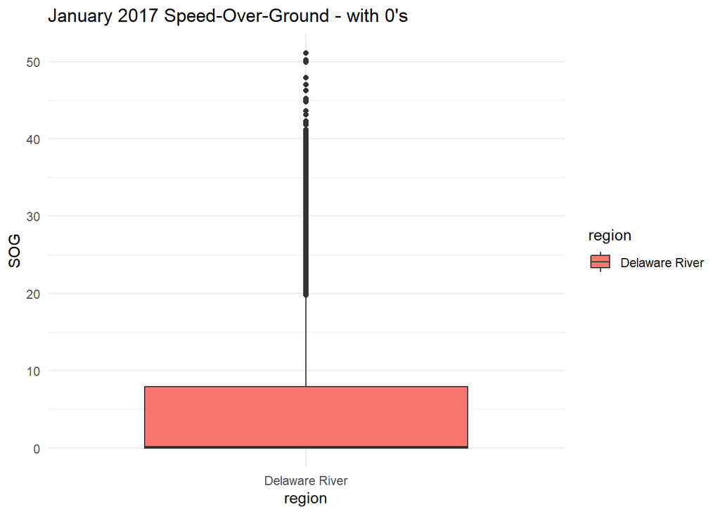

```r
ggplot(Delaware_Riv_Ais_full, aes(region, SOG))+
geom_boxplot(aes(fill = region))+
ggtitle("January 2017 Speed-Over-Ground - with 0's")+
theme_minimal()
```

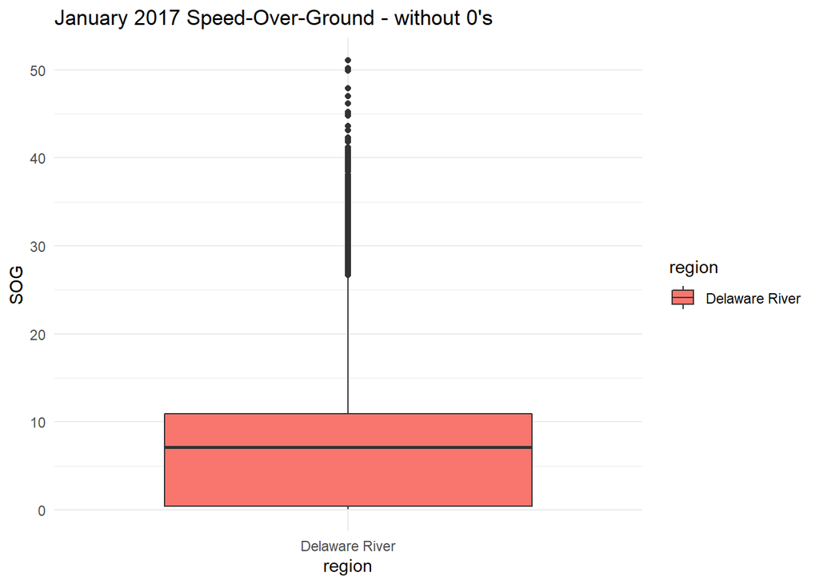

```r
ggplot(data=subset(Delaware_Riv_Ais_full,SOG != 0), aes(region, SOG))+
geom_boxplot(aes(fill = region))+
ggtitle("January 2017 Speed-Over-Ground - without 0's")+
theme_minimal()
```

Now we will look at the distribution of ships by ship type in the dataset

```r
library(plyr)
library(forcats)
Delaware_Riv_Ais_full_joined %>% dplyr::group_by(fct_explicit_na(AVIS.Vessel.Service)) %>% dplyr::summarise(n = n())
```

```
## # A tibble: 12 x 2
##    `fct_explicit_na(AVIS.Vessel.Service)`      n
##    <fct>                                   <int>
##  1 " Commercial Fishing Vessel"             5704
##  2 " Freight Barge"                          263
##  3 " Freight Ship"                        103248
##  4 " Industrial Vessel"                     9319
##  5 " Oil Recovery"                         13815
##  6 " Passenger (Inspected)"               143077
##  7 " Passenger (Uninspected)"               1943
##  8 " Public Vessel, Unclassified"          60786
##  9 " Recreational"                        111145
## 10 " Research Vessel"                      12853
## 11 " Tank Ship"                           118225
## 12 " Towing Vessel"                       449487
```

Now I wanted to look at the distribution of individual ship records, and how many counts the most active ships make.

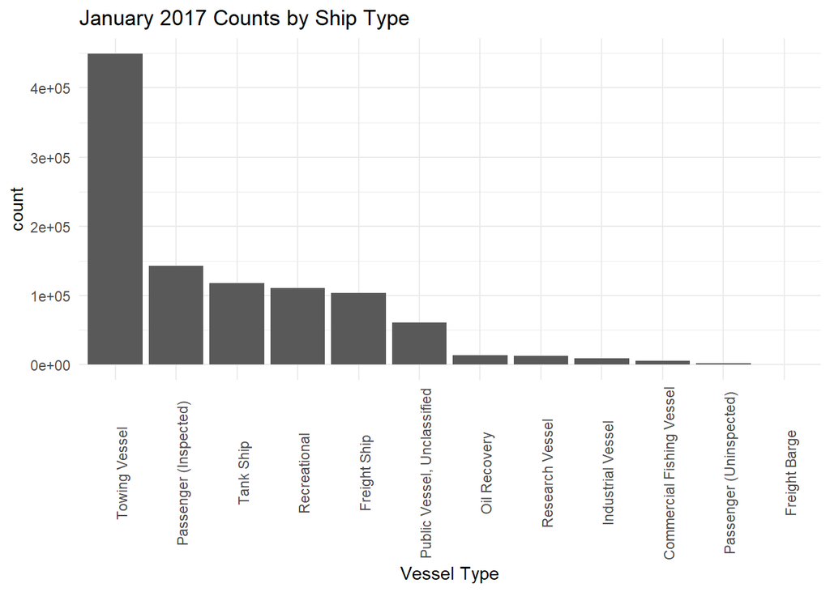

```r
ggplot(Delaware_Riv_Ais_full_joined)+
geom_bar(aes(x = fct_infreq(AVIS.Vessel.Service)))+
ggtitle("January 2017 Counts by Ship Type")+
theme_minimal()+
theme(axis.text.x = element_text(angle = 90))+
xlab("Vessel Type")
```

```r
Delaware_Riv_Ais_full_joined$MMSI  <- as.factor(Delaware_Riv_Ais_full_joined$MMSI)
Delaware_Riv_Ais_full_joined %>% dplyr::group_by(fct_explicit_na(MMSI)) %>% dplyr::summarize(count=n(), "Vessel Type"= first(AVIS.Vessel.Service)) %>% arrange(desc(count)) %>% head(20)
```

```
## # A tibble: 20 x 3
##    `fct_explicit_na(MMSI)` count `Vessel Type`
##    <fct>                   <int> <fct>
##  1 367518270               36076 " Public Vessel, Unclassified"
##  2 367012660               34043 " Towing Vessel"
##  3 367012670               31968 " Towing Vessel"
##  4 367068110               28225 " Passenger (Inspected)"
##  5 367090620               27337 " Passenger (Inspected)"
##  6 367465570               24360 " Towing Vessel"
##  7 338447000               23167 " Towing Vessel"
##  8 367608840               23043 " Towing Vessel"
##  9 367186210               21875 " Towing Vessel"
## 10 367335830               17996 " Towing Vessel"
## 11 367004000               13730 " Passenger (Inspected)"
## 12 369235000               13633 " Towing Vessel"
## 13 367097970               13264 " Towing Vessel"
## 14 367109650               13161 " Oil Recovery"
## 15 367120230               13129 " Towing Vessel"
## 16 636017110               12057 " Tank Ship"
## 17 338193875               12004 " Recreational"
## 18 366914210               11221 " Passenger (Inspected)"
## 19 366902060               10606 " Passenger (Inspected)"
## 20 366999302               10521 " Public Vessel, Unclassified"
```

```r
Delaware_Riv_Ais_full_joined %>% group_by(fct_explicit_na(MMSI)) %>% tally() %>% top_n(10) %>% tally()
```

```
## Using `n` as weighting variable
```

```
## # A tibble: 1 x 1
##        n
##    <int>
## 1 268090
```

Now lets view activity by day of the week (where 1 = Sunday)

```r
Delaware_Riv_Ais_full_joined %>% group_by(fct_explicit_na(wDay)) %>% tally()
```

```
## # A tibble: 7 x 2
##   `fct_explicit_na(wDay)`      n
##   <fct>                    <int>
## 1 1                       132866
## 2 2                       145040
## 3 3                       147105
## 4 4                       136991
## 5 5                       168080
## 6 6                       164417
## 7 7                       135366
```

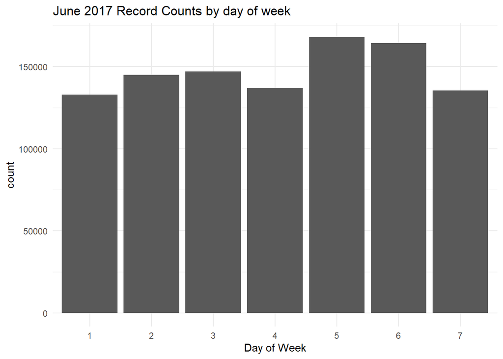

```r
ggplot(Delaware_Riv_Ais_full_joined)+
geom_bar(aes(x = Delaware_Riv_Ais_full_joined$wDay))+
ggtitle("June 2017 Record Counts by day of week")+
theme_minimal()+
xlab("Day of Week")
```